# ProjectWriteUp

Frank

May 22, 2017

## Background

Using devices such as Jawbone Up, Nike FuelBand, and Fitbit it is now possible to collect a large amount of data about personal activity relatively inexpensively. These type of devices are part of the quantified self movement - a group of enthusiasts who take measurements about themselves regularly to improve their health, to find patterns in their behavior, or because they are tech geeks. One thing that people regularly do is quantify how much of a particular activity they do, but they rarely quantify how well they do it. In this project, your goal will be to use data from accelerometers on the belt, forearm, arm, and dumbell of 6 participants. They were asked to perform barbell lifts correctly and incorrectly in 5 different ways. More information is available from the website here: http://groupware.les.inf.puc-rio.br/har (see the section on the Weight Lifting Exercise Dataset).

## Data

The training data for this project are available here:

https://d396qusza40orc.cloudfront.net/predmachlearn/pml-training.csv

The test data are available here:

https://d396qusza40orc.cloudfront.net/predmachlearn/pml-testing.csv

The data for this project come from this source: http://groupware.les.inf.puc-rio.br/har. If you use the document you create for this class for any purpose please cite them as they have been very generous in allowing their data to be used for this kind of assignment.

```r
library(lattice)
library(ggplot2)
library(graphics)
library(e1071)
library(caret)
library(rpart.plot)
library(rpart)
library(rattle)
library(randomForest)
library(RColorBrewer)
```

# Load & Verify Data

First step is to load clean data from both the testing and the training datasets:

```r
trainUrl <- "http://d396qusza40orc.cloudfront.net/predmachlearn/pml-training.csv"
testUrl <- "http://d396qusza40orc.cloudfront.net/predmachlearn/pml-testing.csv"

training <- read.csv(url(trainUrl), na.strings=c("NA","#DIV/0!",""))
testing <- read.csv(url(testUrl), na.strings=c("NA","#DIV/0!",""))
```

Next, we then separate the data to be used for cross verification:

```r
inTrain <- createDataPartition(y=training$classe, p=0.6, list=FALSE)
myDataTrain <- training[inTrain, ];
myDataTest <- training[-inTrain, ]
```

We then examine the size and structure of the data (respectively):

```r
dim(myDataTrain)
```

```
## [1] 11776   160
```

```r
dim(myDataTest)
```

```
## [1] 7846  160
```

## Data Clean Up

```r
nzv <- nearZeroVar(myDataTrain, saveMetrics=TRUE)
myDataTrain <- myDataTrain[,nzv$nzv==FALSE]

nzv<- nearZeroVar(myDataTest,saveMetrics=TRUE)
myTesting <- myDataTest[,nzv$nzv==FALSE]

#Remove the first column of the myTraining data set
myDataTrain <- myDataTrain[c(-1)]

#Clean variables with more than 60% NA
trainingV3 <- myDataTrain
for(i in 1:length(myDataTrain)) {
        if( sum( is.na( myDataTrain[, i] ) ) /nrow(myDataTrain) >= .7) {
                for(j in 1:length(trainingV3)) {
                        if( length( grep(names(myDataTrain[i]), names(trainingV3)[j]) ) == 1)  {
                                trainingV3 <- trainingV3[ , -j]
                        }
                }
        }
}

myDataTrain <- trainingV3
rm(trainingV3)

clean1 <- colnames(myDataTrain)
clean2 <- colnames(myDataTrain[, -58])
myTesting <- myDataTest[clean1]
testing <- testing[clean2]

for (i in 1:length(testing) ) {
        for(j in 1:length(myDataTrain)) {
                if( length( grep(names(myDataTrain[i]), names(testing)[j]) ) == 1)  {
                        class(testing[j]) <- class(myDataTrain[i])
                }
        }
}

testing <- rbind(myDataTrain[2, -58] , testing)
testing <- testing[-1,]
```

# Random Forest Prediction

```r
set.seed(12345)
modFitB1 <- randomForest(classe ~ ., data=myDataTrain)
predictionB1 <- predict(modFitB1, myDataTest, type = "class")
cmrf <- confusionMatrix(predictionB1, myDataTest$classe)
cmrf
```

```
## Confusion Matrix and Statistics
##
##           Reference
## Prediction    A    B    C    D    E
##          A 2230    2    0    0    0
##          B    2 1516    3    0    0
##          C    0    0 1364    1    0
##          D    0    0    1 1285    3
##          E    0    0    0    0 1439
##
## Overall Statistics
##
##                Accuracy : 0.9985
##                  95% CI : (0.9973, 0.9992)
##     No Information Rate : 0.2845
##     P-Value [Acc > NIR] : < 2.2e-16
##
##                   Kappa : 0.9981
##  Mcnemar's Test P-Value : NA
##
## Statistics by Class:
##
##                      Class: A Class: B Class: C Class: D Class: E
## Sensitivity            0.9991   0.9987   0.9971   0.9992   0.9979
## Specificity            0.9996   0.9992   0.9998   0.9994   1.0000
## Pos Pred Value         0.9991   0.9967   0.9993   0.9969   1.0000
## Neg Pred Value         0.9996   0.9997   0.9994   0.9998   0.9995
## Prevalence             0.2845   0.1935   0.1744   0.1639   0.1838
## Detection Rate         0.2842   0.1932   0.1738   0.1638   0.1834
## Detection Prevalence   0.2845   0.1939   0.1740   0.1643   0.1834
## Balanced Accuracy      0.9994   0.9989   0.9985   0.9993   0.9990
```

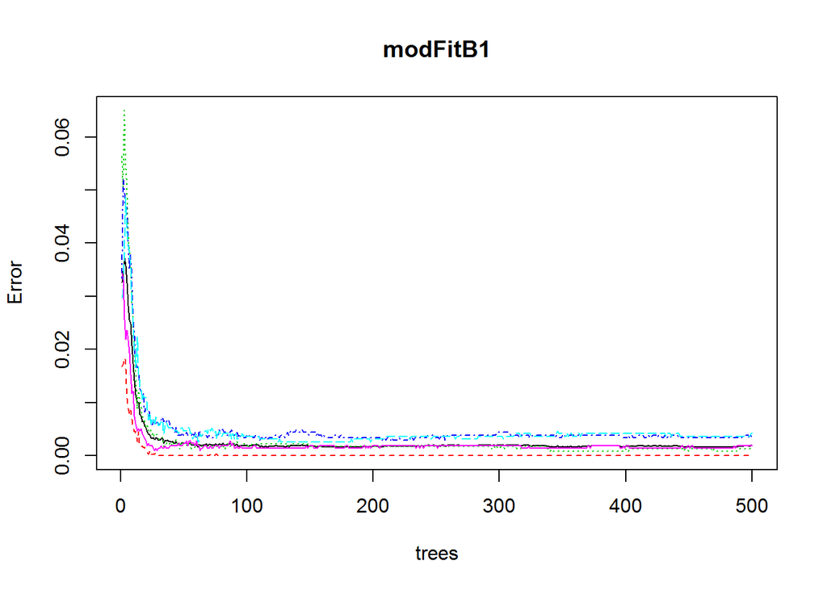

```r
plot(modFitB1)
```

##Decision Trees

[figure not shown]

```r
set.seed(12345)
modFitA1 <- rpart(classe ~ ., data=myDataTrain, method="class")
fancyRpartPlot(modFitA1)
```

```r
predictionsA1 <- predict(modFitA1, myDataTest, type = "class")
cmtree <- confusionMatrix(predictionsA1, myDataTest$classe)
cmtree
```

```
## Confusion Matrix and Statistics
##
##           Reference
## Prediction    A    B    C    D    E
##          A 2143   56    3    4    0
##          B   65 1282   71   69    0
##          C   24  172 1267  145   54
##          D    0    8   27 1012  185
##          E    0    0    0   56 1203
##
## Overall Statistics
##
##                Accuracy : 0.8803
##                  95% CI : (0.8729, 0.8874)
##     No Information Rate : 0.2845
##     P-Value [Acc > NIR] : < 2.2e-16
##
##                   Kappa : 0.8487
##  Mcnemar's Test P-Value : NA
##
## Statistics by Class:
##
##                      Class: A Class: B Class: C Class: D Class: E
## Sensitivity            0.9601   0.8445   0.9262   0.7869   0.8343
## Specificity            0.9888   0.9676   0.9390   0.9665   0.9913
## Pos Pred Value         0.9714   0.8621   0.7623   0.8214   0.9555
## Neg Pred Value         0.9842   0.9629   0.9837   0.9586   0.9637
## Prevalence             0.2845   0.1935   0.1744   0.1639   0.1838
## Detection Rate         0.2731   0.1634   0.1615   0.1290   0.1533
## Detection Prevalence   0.2812   0.1895   0.2118   0.1570   0.1605
## Balanced Accuracy      0.9745   0.9061   0.9326   0.8767   0.9128
```

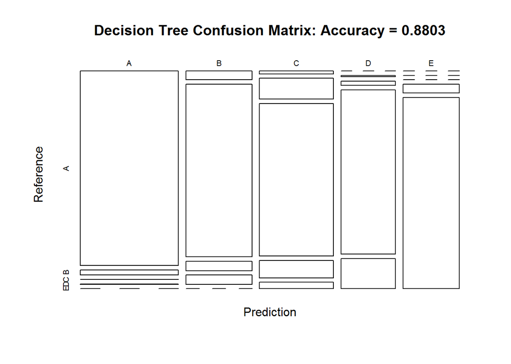

```r
plot(cmtree$table, col = cmtree$byClass, main = paste("Decision Tree Confusion Matrix: Accuracy =", round(cmtree$overall['Accuracy'], 4)))
```